# Programming Languages für Data Science

Major Assignment: Flight Analysis - Data Preparation and first Insights

Christian Roth & Andreas Waßmus

22.10.2019

# 1 Data Preparation

## 1.1 Libraries and Data

```r
library(tidyverse)
library(readr)
library(DataExplorer)
```

Loading the data:

```r
usflights <- read_csv("./data/flight-delays/usflights15.csv")
nrow(usflights)
```

```
## [1] 5819079
```

The data contains 5.819.079 datasets (=count of flights in the US in 2015)

```r
head(usflights)
```

```
## # A tibble: 6 x 31
##    YEAR MONTH   DAY DAY_OF_WEEK AIRLINE FLIGHT_NUMBER TAIL_NUMBER
##   <dbl> <dbl> <dbl>       <dbl> <chr>           <dbl> <chr>
## 1  2015     1     1           4 AS                 98 N407AS
## 2  2015     1     1           4 AA               2336 N3KUAA
## 3  2015     1     1           4 US                840 N171US
## 4  2015     1     1           4 AA                258 N3HYAA
## 5  2015     1     1           4 AS                135 N527AS
## 6  2015     1     1           4 DL                806 N3730B
## # … with 24 more variables: ORIGIN_AIRPORT <chr>,
## #   DESTINATION_AIRPORT <chr>, SCHEDULED_DEPARTURE <chr>,
## #   DEPARTURE_TIME <chr>, DEPARTURE_DELAY <dbl>, TAXI_OUT <dbl>,
## #   WHEELS_OFF <chr>, SCHEDULED_TIME <dbl>, ELAPSED_TIME <dbl>,
## #   AIR_TIME <dbl>, DISTANCE <dbl>, WHEELS_ON <chr>, TAXI_IN <dbl>,
## #   SCHEDULED_ARRIVAL <chr>, ARRIVAL_TIME <chr>, ARRIVAL_DELAY <dbl>,
## #   DIVERTED <dbl>, CANCELLED <dbl>, CANCELLATION_REASON <chr>,
## #   AIR_SYSTEM_DELAY <dbl>, SECURITY_DELAY <dbl>, AIRLINE_DELAY <dbl>,
## #   LATE_AIRCRAFT_DELAY <dbl>, WEATHER_DELAY <dbl>
```

Important features for analysis: Date Airline Flight_Number Origin_Airport Destination_Arport Scheduled_Departure Departure Time Departure Delay

## 1.2 Missing values in the flight data

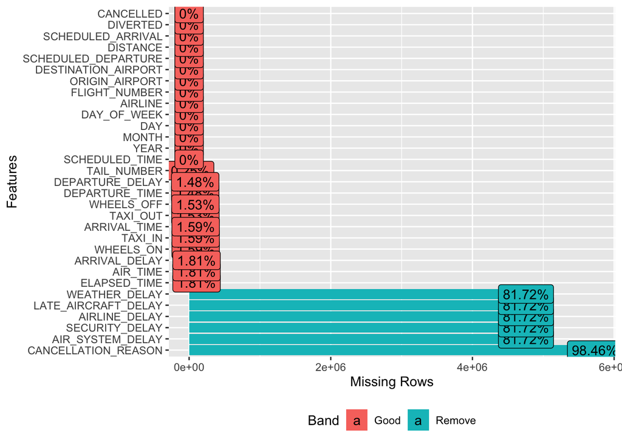

```r
plot_missing(usflights)
```

You can also count the missing value per column with this function:

```r
#is.na(usflights)
colSums(is.na(usflights))
```

```
##                YEAR               MONTH                 DAY
##                   0                   0                   0
##         DAY_OF_WEEK             AIRLINE       FLIGHT_NUMBER
##                   0                   0                   0
##         TAIL_NUMBER      ORIGIN_AIRPORT DESTINATION_AIRPORT
##               14721                   0                   0
## SCHEDULED_DEPARTURE      DEPARTURE_TIME     DEPARTURE_DELAY
##                   0               86153               86153
##            TAXI_OUT          WHEELS_OFF      SCHEDULED_TIME
##               89047               89047                   6
##        ELAPSED_TIME            AIR_TIME            DISTANCE
##              105071              105071                   0
##           WHEELS_ON             TAXI_IN   SCHEDULED_ARRIVAL
##               92513               92513                   0
##        ARRIVAL_TIME       ARRIVAL_DELAY            DIVERTED
##               92513              105071                   0
##           CANCELLED CANCELLATION_REASON    AIR_SYSTEM_DELAY
##                   0             5729195             4755640
##      SECURITY_DELAY       AIRLINE_DELAY LATE_AIRCRAFT_DELAY
##             4755640             4755640             4755640
##       WEATHER_DELAY
##             4755640
```

In the dataset there is a high amount of missing values in the features: CANCELLATION_REASON, AIR_SYSTEM_DELAY, SECURITY_DELAY, AIRLINE_DELAY, LATE_AIRCRAFT_DELAY, WEATHER_DELAY. Since these colums are only explanations of the features cancellation and delay we can remove them from the dataset.

```r
usflights$CANCELLATION_REASON <- NULL
usflights$AIR_SYSTEM_DELAY <- NULL
usflights$SECURITY_DELAY <- NULL
usflights$AIRLINE_DELAY <- NULL
usflights$LATE_AIRCRAFT_DELAY <- NULL
usflights$WEATHER_DELAY <- NULL
head(usflights, 3)
```

```
## # A tibble: 3 x 25
##    YEAR MONTH   DAY DAY_OF_WEEK AIRLINE FLIGHT_NUMBER TAIL_NUMBER
##   <dbl> <dbl> <dbl>       <dbl> <chr>           <dbl> <chr>
## 1  2015     1     1           4 AS                 98 N407AS
## 2  2015     1     1           4 AA               2336 N3KUAA
## 3  2015     1     1           4 US                840 N171US
## # … with 18 more variables: ORIGIN_AIRPORT <chr>,
## #   DESTINATION_AIRPORT <chr>, SCHEDULED_DEPARTURE <chr>,
## #   DEPARTURE_TIME <chr>, DEPARTURE_DELAY <dbl>, TAXI_OUT <dbl>,
## #   WHEELS_OFF <chr>, SCHEDULED_TIME <dbl>, ELAPSED_TIME <dbl>,
## #   AIR_TIME <dbl>, DISTANCE <dbl>, WHEELS_ON <chr>, TAXI_IN <dbl>,
## #   SCHEDULED_ARRIVAL <chr>, ARRIVAL_TIME <chr>, ARRIVAL_DELAY <dbl>,
## #   DIVERTED <dbl>, CANCELLED <dbl>
```

```r
colSums(is.na(usflights))
```

```
##                YEAR               MONTH                 DAY
##                   0                   0                   0
##         DAY_OF_WEEK             AIRLINE       FLIGHT_NUMBER
##                   0                   0                   0
##         TAIL_NUMBER      ORIGIN_AIRPORT DESTINATION_AIRPORT
##               14721                   0                   0
## SCHEDULED_DEPARTURE      DEPARTURE_TIME     DEPARTURE_DELAY
##                   0               86153               86153
##            TAXI_OUT          WHEELS_OFF      SCHEDULED_TIME
##               89047               89047                   6
##        ELAPSED_TIME            AIR_TIME            DISTANCE
##              105071              105071                   0
##           WHEELS_ON             TAXI_IN   SCHEDULED_ARRIVAL
##               92513               92513                   0
##        ARRIVAL_TIME       ARRIVAL_DELAY            DIVERTED
##               92513              105071                   0
##           CANCELLED
##                   0
```

For the analysis it is for us important to have a complete datasets. Therefore, rows with missing values will be deleted to have only complete observations. (ARRIVAL_DELAY could be also calculated by “mutate”. For simplification it is waived due to the large number of records.)

```r
usflights_complete <- usflights[!is.na(usflights$DEPARTURE_TIME),]
usflights_complete <- usflights[!is.na(usflights$ARRIVAL_TIME),]
usflights_complete <- usflights[!is.na(usflights$ARRIVAL_DELAY),]
```

Check if data is complete and without missing values:

```r
colSums(is.na(usflights_complete))
```

```
##                YEAR               MONTH                 DAY
##                   0                   0                   0
##         DAY_OF_WEEK             AIRLINE       FLIGHT_NUMBER
##                   0                   0                   0
##         TAIL_NUMBER      ORIGIN_AIRPORT DESTINATION_AIRPORT
##                   0                   0                   0
## SCHEDULED_DEPARTURE      DEPARTURE_TIME     DEPARTURE_DELAY
##                   0                   0                   0
##            TAXI_OUT          WHEELS_OFF      SCHEDULED_TIME
##                   0                   0                   0
##        ELAPSED_TIME            AIR_TIME            DISTANCE
##                   0                   0                   0
##           WHEELS_ON             TAXI_IN   SCHEDULED_ARRIVAL
##                   0                   0                   0
##        ARRIVAL_TIME       ARRIVAL_DELAY            DIVERTED
##                   0                   0                   0
##           CANCELLED
##                   0
```

```r
nrow(usflights_complete)
```

```
## [1] 5714008
```

105.071 data sets were reomved from the analyse. The data has now 5.714.008 oberservations.

## 1.3 Merge flight data with arilines und airports

Read csv and save as data frame:

```r
airlines2015 <- read_csv("./data/flight-delays/airlines15.csv")
airports2015 <- read_csv("./data/flight-delays/airports15.csv")
```

Overview of the data:

```r
data_list_2015 <- list(airlines2015, airports2015, usflights)
plot_str(data_list_2015)
```

Merge df airlines2015 to flight dataset:

```r
flights2015 <- merge(usflights_complete, airlines2015, by.x= "AIRLINE", by.y="IATA_CODE", all.x = TRUE)
```

Merge df airports2015 to flight dataset:

```r
flights2015_merged <- merge(flights2015, airports2015, by.x = "ORIGIN_AIRPORT", by.y = "IATA_CODE", all.x = TRUE)
```

Check if merge has worked successfully:

```r
head(flights2015_merged)
```

```
##   ORIGIN_AIRPORT AIRLINE YEAR MONTH DAY DAY_OF_WEEK FLIGHT_NUMBER
## 1          10135      EV 2015    10  23           5          6144
## 2          10135      EV 2015    10  22           4          6021
## 3          10135      EV 2015    10   1           4          5145
## 4          10135      EV 2015    10  23           5          6011
## 5          10135      EV 2015    10   6           2          5145
## 6          10135      DL 2015    10  28           3          2561
##   TAIL_NUMBER DESTINATION_AIRPORT SCHEDULED_DEPARTURE DEPARTURE_TIME
## 1      N13118               13930                1722           1713
## 2      N12924               13930                0649           0641
## 3      N849AS               11433                1711           1711
## 4      N11551               13930                1205           1157
## 5      N856AS               11433                1711           1708
## 6      N892AT               10397                0600           0559
##   DEPARTURE_DELAY TAXI_OUT WHEELS_OFF SCHEDULED_TIME ELAPSED_TIME AIR_TIME
```

[output cut: 27 more lines]

## 1.4 Missing values in the merged data

Check missing values per column:

```r
colSums(is.na(flights2015_merged))
```

```
##      ORIGIN_AIRPORT             AIRLINE                YEAR
##                   0                   0                   0
##               MONTH                 DAY         DAY_OF_WEEK
##                   0                   0                   0
##       FLIGHT_NUMBER         TAIL_NUMBER DESTINATION_AIRPORT
##                   0                   0                   0
## SCHEDULED_DEPARTURE      DEPARTURE_TIME     DEPARTURE_DELAY
##                   0                   0                   0
##            TAXI_OUT          WHEELS_OFF      SCHEDULED_TIME
##                   0                   0                   0
##        ELAPSED_TIME            AIR_TIME            DISTANCE
##                   0                   0                   0
##           WHEELS_ON             TAXI_IN   SCHEDULED_ARRIVAL
##                   0                   0                   0
##        ARRIVAL_TIME       ARRIVAL_DELAY            DIVERTED
##                   0                   0                   0
##           CANCELLED           AIRLINE.y             AIRPORT
##                   0                   0              482878
##                CITY               STATE             COUNTRY
##              482878              482878              482878
##            LATITUDE           LONGITUDE
##              487439              487439
```

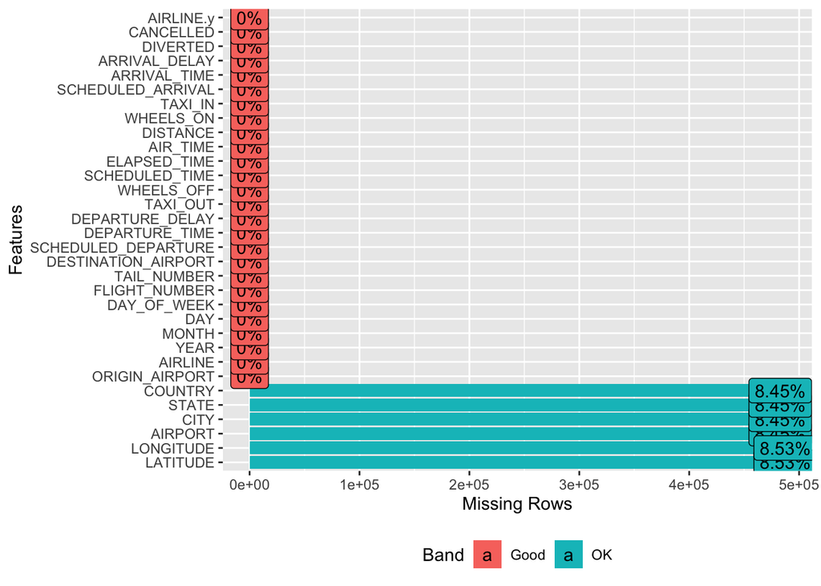

```r
plot_missing(flights2015_merged)
```

As bevor mentioned, it is important for the analysis to have complete datasets. Therefore, the above shown features with missing values will be deleted.

```r
flights2015_merged_complete <- flights2015_merged[!is.na(flights2015_merged$COUNTRY),]
flights2015_merged_complete <- flights2015_merged[!is.na(flights2015_merged$STATE),]
flights2015_merged_complete <- flights2015_merged[!is.na(flights2015_merged$CITY),]
flights2015_merged_complete <- flights2015_merged[!is.na(flights2015_merged$AIRPORT),]
flights2015_merged_complete <- flights2015_merged[!is.na(flights2015_merged$LONGITUDE),]
flights2015_merged_complete <- flights2015_merged[!is.na(flights2015_merged$LATITUDE),]
```

Check if all rows with missing value are excluded from the analysis.

```r
colSums(is.na(flights2015_merged_complete))
```

```
##      ORIGIN_AIRPORT             AIRLINE                YEAR
##                   0                   0                   0
##               MONTH                 DAY         DAY_OF_WEEK
##                   0                   0                   0
##       FLIGHT_NUMBER         TAIL_NUMBER DESTINATION_AIRPORT
##                   0                   0                   0
## SCHEDULED_DEPARTURE      DEPARTURE_TIME     DEPARTURE_DELAY
##                   0                   0                   0
##            TAXI_OUT          WHEELS_OFF      SCHEDULED_TIME
##                   0                   0                   0
##        ELAPSED_TIME            AIR_TIME            DISTANCE
##                   0                   0                   0
##           WHEELS_ON             TAXI_IN   SCHEDULED_ARRIVAL
##                   0                   0                   0
##        ARRIVAL_TIME       ARRIVAL_DELAY            DIVERTED
##                   0                   0                   0
##           CANCELLED           AIRLINE.y             AIRPORT
##                   0                   0                   0
##                CITY               STATE             COUNTRY
##                   0                   0                   0
##            LATITUDE           LONGITUDE
##                   0                   0
```

```r
nrow(flights2015_merged_complete)
```

```
## [1] 5226569
```

The data has 5.226.569 complete oberservations. Starting from 5.819.079 rows, this represants a reduction of 592.510 or 10,2%.

```r
nrow(flights2015_merged)
```

```
## [1] 5714008
```

## 1.5 Building DEPARTURE_DATE From the columns YEAR, MONTH and DAY.

This step makes our analysis easier and is important for showing flight movements in a map for each day.

```r
flights2015_merged_complete$DEPARTURE_DATE <- as.Date(with(flights2015_merged_complete, paste(YEAR, MONTH, DAY, sep = "-")),"%Y-%m-%d")
head(flights2015_merged_complete$DEPARTURE_DATE)
```

```
## [1] "2015-02-20" "2015-08-04" "2015-01-25" "2015-11-07" "2015-02-17"
## [6] "2015-01-29"
```

## 1.6 Creation of 3 data frames and save as .csv

### 1.6.1 Complete data

For further processing we save a csv from this dataframe:

```r
write.csv(flights2015_merged_complete,("./data/cleandata/flights15_complete.csv"))
```

### 1.6.2 Christmas data 2015 (23.12.-26.12.)

In fact it is very hard to work with such a big dataframe and every analysis will take a lot of time. Therefore, we decided to conduct a Christmas Flight Study in 2015 and we will work with a smaler data frame:

```r
christmas15 <- filter(flights2015_merged_complete, DEPARTURE_DATE >="2015-12-23" & DEPARTURE_DATE <= "2015-12-26")
```

56.246 oberservations were selected for the further analysis:

```r
nrow(christmas15)
```

```
## [1] 56246
```

```r
#write.csv(christmas15,("./data/cleandata/christmas15.csv"))
```

Dataset for an animated flight map:

```r
christmasDay15 <- filter(christmas15, DEPARTURE_DATE == "2015-12-25" & ORIGIN_AIRPORT == "JFK" | DESTINATION_AIRPORT == "JFK")
head(christmasDay15)
```

```
##   ORIGIN_AIRPORT AIRLINE YEAR MONTH DAY DAY_OF_WEEK FLIGHT_NUMBER
## 1            ABQ      B6 2015    12  24           4            66
## 2            ABQ      B6 2015    12  25           5            66
## 3            ABQ      B6 2015    12  26           6            66
## 4            ABQ      B6 2015    12  23           3            66
## 5            ATL      DL 2015    12  26           6           843
## 6            ATL      DL 2015    12  24           4           478
##   TAIL_NUMBER DESTINATION_AIRPORT SCHEDULED_DEPARTURE DEPARTURE_TIME
## 1      N506JB                 JFK                2359           0031
## 2      N588JB                 JFK                2359           2359
## 3      N585JB                 JFK                2359           0023
## 4      N558JB                 JFK                2359           0056
## 5      N712TW                 JFK                1000           1014
## 6       N6702                 JFK                1235           1817
##   DEPARTURE_DELAY TAXI_OUT WHEELS_OFF SCHEDULED_TIME ELAPSED_TIME AIR_TIME
```

[output cut: 34 more lines]

```r
nrow(christmasDay15)
```

```
## [1] 1299
```

```r
christmasDay15_sample <- sample_n(christmasDay15, 50)
head(christmasDay15_sample)
```

```
##   ORIGIN_AIRPORT AIRLINE YEAR MONTH DAY DAY_OF_WEEK FLIGHT_NUMBER
## 1            SFO      AA 2015    12  26           6            16
## 2            BUF      B6 2015    12  26           6          2601
## 3            TPA      DL 2015    12  26           6           410
## 4            BUR      B6 2015    12  26           6           358
## 5            BUF      B6 2015    12  25           5          2301
## 6            JFK      B6 2015    12  25           5            23
##   TAIL_NUMBER DESTINATION_AIRPORT SCHEDULED_DEPARTURE DEPARTURE_TIME
## 1      N785AA                 JFK                1235           1228
## 2      N304JB                 JFK                1640           1914
## 3      N951AT                 JFK                1510           1517
## 4      N552JB                 JFK                2145           2144
## 5      N535JB                 JFK                1015           1150
## 6      N946JB                 LAX                0710           0710
##   DEPARTURE_DELAY TAXI_OUT WHEELS_OFF SCHEDULED_TIME ELAPSED_TIME AIR_TIME
```

[output cut: 34 more lines]

```r
#write.csv(christmasDay15,("./data/cleandata/christmasDay15.csv"))
```

```r
#write.csv(christmasDay15_sample,("./data/cleandata/christmasDay15_sample.csv"))
```

# 2. Introduction Flights 2015 (complete data)

Plotting the whole data takes a while… As an example we show some plots of the total data we have in 2015. In the first plot, DISTANCE of a flight is shown on the x-axis and the ARRIVAL_DELAY on y. You can see that the majority of the flights (doesn´t matter which distance) has only a little delay, close to 0. Many flights also arrive before their sceduled ARRIVAL_TIME at the DESTINATION_AIRPORT. But we also have a lot of observations where we see extreme delays up to 2000 minutes in every distance in the US.

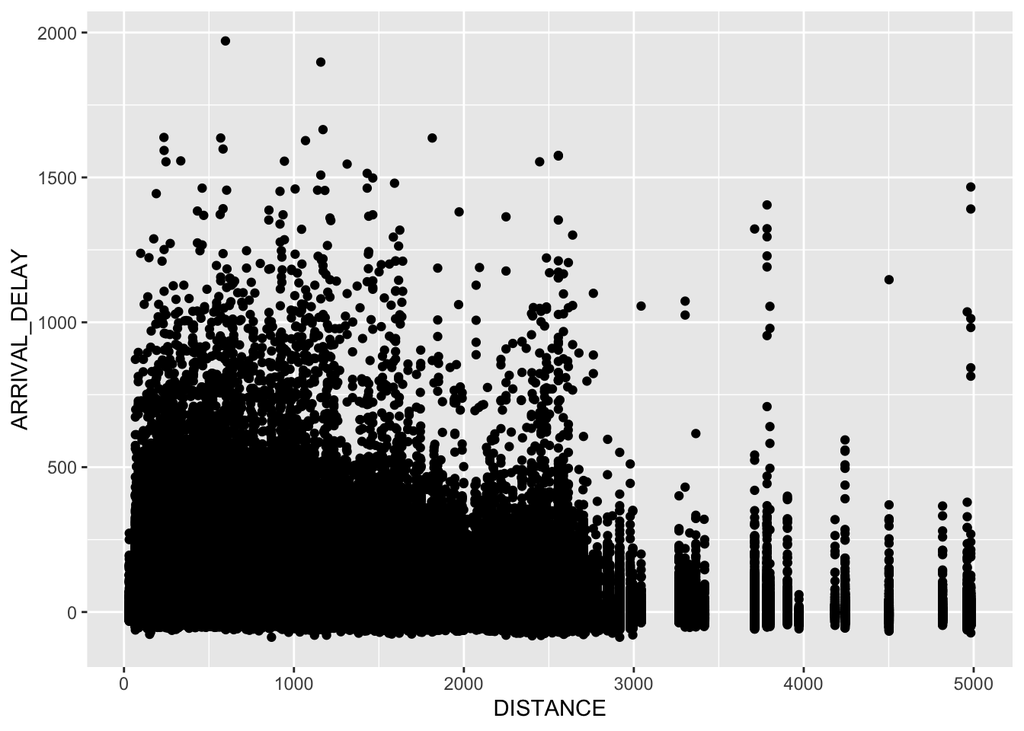

```r
p1 <- ggplot(flights2015_merged_complete, aes(DISTANCE, ARRIVAL_DELAY)) +
   geom_point()
p1
```

The following plot is supporting this impression by visualizing that all boxplots are very close to 0 (some are even earlier than the scheduled arrival). At the same time it shows the spread of delays for each airline. And these delays cause customers to get a bad impressionfrom an airline.

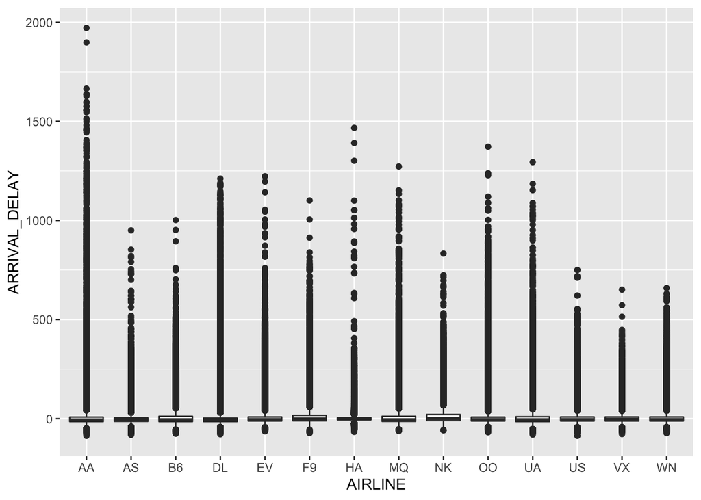

```r
p2<- ggplot(flights2015_merged_complete, aes(AIRLINE , ARRIVAL_DELAY)) +
   geom_boxplot()
p2
```

Let´s have a closer look to some statistics:

ARRIVAL_DELAY:

```r
flights2015_merged_complete %>%
  group_by(AIRLINE.y) %>%
  summarise (count = n(),
            mean_arrival_delay = mean(ARRIVAL_DELAY),
            median_arrival_delay = median(ARRIVAL_DELAY),
            max_arrival_delay = max(ARRIVAL_DELAY),
            min_arrival_delay = min(ARRIVAL_DELAY)) %>%
  arrange(desc(count))
```

```
## # A tibble: 14 x 6
##    AIRLINE.y  count mean_arrival_de… median_arrival_… max_arrival_del…
##    <chr>      <int>            <dbl>            <dbl>            <dbl>
##  1 Southwes… 1.14e6            4.85                -4              659
##  2 Delta Ai… 7.93e5            0.679               -7             1211
##  3 American… 6.37e5            3.94                -6             1971
##  4 Skywest … 5.28e5            6.22                -4             1372
##  5 Atlantic… 5.09e5            6.97                -4             1223
##  6 United A… 4.62e5            6.21                -5             1294
##  7 American… 2.57e5            7.32                -5             1272
##  8 JetBlue … 2.40e5            6.95                -5             1002
##  9 US Airwa… 1.94e5            3.71                -4              750
## 10 Alaska A… 1.57e5           -0.791               -5              950
## 11 Spirit A… 1.05e5           15.2                  1              833
## 12 Frontier… 8.19e4           13.7                 -1             1101
## 13 Hawaiian… 6.98e4            2.16                -2             1467
## 14 Virgin A… 5.58e4            4.98                -3              651
## # … with 1 more variable: min_arrival_delay <dbl>
```

DEPARTURE_DELAY:

```r
flights2015_merged_complete %>%
  group_by(AIRLINE) %>%
  summarise (mean_departure_delay = mean(DEPARTURE_DELAY),
            median_departure_delay = median(DEPARTURE_DELAY),
            max_departure_delay = max(DEPARTURE_DELAY),
            min_departure_delay = min(DEPARTURE_DELAY))
```

```
## # A tibble: 14 x 5
##    AIRLINE mean_departure_… median_departur… max_departure_d…
##    <chr>              <dbl>            <dbl>            <dbl>
##  1 AA                 9.25                -2             1988
##  2 AS                 1.89                -4              963
##  3 B6                11.8                 -2             1006
##  4 DL                 7.71                -1             1228
##  5 EV                 8.98                -3             1236
##  6 F9                14.2                 -2             1112
##  7 HA                 0.497               -4             1433
##  8 MQ                10.5                 -2             1278
##  9 NK                16.6                  0              836
## 10 OO                 8.11                -3             1378
## 11 UA                15.0                  1             1314
## 12 US                 6.08                -2              759
## 13 VX                 9.18                -1              644
## 14 WN                10.9                  0              665
## # … with 1 more variable: min_departure_delay <dbl>
```

First, we have to build a new data frame:

```r
flights2015_delay10 <- flights2015_merged_complete %>%
  group_by(AIRLINE) %>%
  filter(ARRIVAL_DELAY > 10)
```

1.182.848 flights are delayed more than 10 minutes. That is a percentage of 22,6% - almost a quarter of the flights:

```r
nrow(flights2015_delay10)
```

```
## [1] 1182848
```

```r
percentage <- nrow(flights2015_delay10) / nrow(flights2015_merged_complete)
percentage
```

```
## [1] 0.2263144
```

Statistics for flights with a arrival delay > 10 minutes:

```r
flights2015_delay10 %>%
  group_by(AIRLINE.y) %>%
  summarise (count = n(),
            mean_arrival_delay = mean(ARRIVAL_DELAY),
            median_arrival_delay = median(ARRIVAL_DELAY),
            max_arrival_delay = max(ARRIVAL_DELAY),
            min_arrival_delay = min(ARRIVAL_DELAY)) %>%
  arrange(desc(count))
```

```
## # A tibble: 14 x 6
##    AIRLINE.y  count mean_arrival_de… median_arrival_… max_arrival_del…
##    <chr>      <int>            <dbl>            <dbl>            <dbl>
##  1 Southwes… 265819             46.1               29              659
##  2 American… 141683             53.0               31             1971
##  3 Delta Ai… 134181             53.3               29             1211
##  4 Atlantic… 120527             55.4               33             1223
##  5 Skywest … 120010             53.1               32             1372
##  6 United A… 114488             57.8               35             1294
##  7 American…  66493             56.6               36             1272
##  8 JetBlue …  63083             55.4               35             1002
##  9 US Airwa…  44307             43.7               27              750
## 10 Spirit A…  36360             57.6               37              833
## 11 Alaska A…  26023             41.1               25              950
## 12 Frontier…  25674             60.8               35             1101
## 13 Virgin A…  13179             48.7               30              651
## 14 Hawaiian…  11021             32.4               20             1467
## # … with 1 more variable: min_arrival_delay <dbl>
```

We can see that the mean_arrival_delay and median_arrival_delay is higher than in the complete data. For almost a quarter of al flights passenger have to deal with a significant delay.

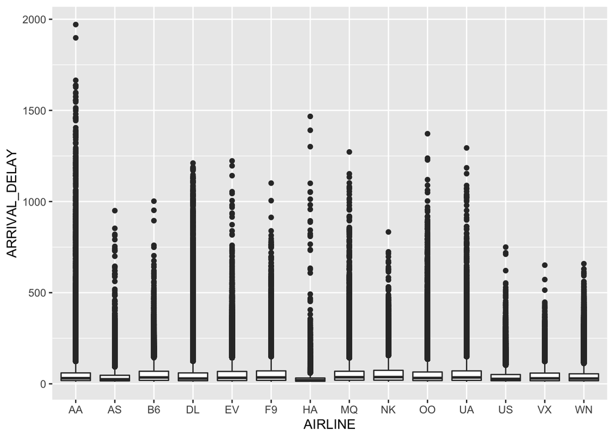

```r
p3<- ggplot(flights2015_delay10, aes(AIRLINE , ARRIVAL_DELAY)) +
   geom_boxplot()
p3
```

This was first impression of the complete data. For the further analysis we will change the data frame and work with the Christmas flight data in 2015.